# CRISPR-Cas9 Validation

Scott Campit

# Summary

This notebook does the following analysis: 1. Separate out lung cancer cell lines 2. Compute differentially expressed CS 3. Compare it to current iteration of metabolic reactions and genes predicted by COBRA

# 1. Load libraries

```r
library(tidyr)
library(readr)
library(stringr)
library(ggplot2)
library(reticulate)
library(limma)
library(Glimma)
library(edgeR)
library(tidyverse)
library(dplyr)
library(reshape2)
library(readxl)
library(ggVennDiagram)
library(rrcov)
```

# 2. Read in data

```r
rm(list=ls())

# Dell
datapath = 'D:/Data/CRISPR/Achilles/Achilles_gene_effect.csv'

# Linux
#datapath = '~/Data/CRISPR/Achilles_gene_effect.csv'

# Read in data
data = readr::read_csv(datapath)
```

# 3. Perform Robust PCA to remove bad cell line and gene data

First, we’ll grab the CERES Scores.

```r
ceres = data[, 2:ncol(data)]
ceres = data.matrix(ceres)
ceres[is.na(ceres)] = 0
ceres = as.matrix(ceres)
ids = data.frame(data[, 1])
```

First, we’ll create a function that can perform ROBPCA on the data.

```r
# Create a function that filters data using ROBPCA
removeOutliers = function(data, id){
  pca_obj = PcaHubert(data)
  filtered_data = data[pca_obj@flag, ]
  filtered_id = id[pca_obj@flag,]
  outlier_data = data[!pca_obj@flag, ]
  outlier_id = id[!pca_obj@flag,]

  setClass(Class="geneObj",
           representation(
             data="matrix",
             outlier_data="matrix",
             id="character",
             flag="logical",
             outlier_id="character",
             robpca='PcaHubert'
           )
   )
   return(new("geneObj",
          data=filtered_data,
          outlier_data=outlier_data,
          id=filtered_id,
          flag=pca_obj@flag,
          outlier_id=outlier_id,
          robpca=pca_obj))
}
```

## Perform PCA

```r
pca_obj = prcomp(ceres, scale=FALSE)
```

## Visualize PCA Scores Plot

Let’s visualize the original PCA dimension reduction.

```r
scores = data.frame(pca_obj[["x"]])
ggplot(scores, aes(x=PC1, y=PC2)) +
  geom_point() +
  labs(title="CERES Scores Plot",
       x="PC1",
       y="PC2") +
  theme(legend.position="none")
```

[output not shown]

## Robust PCA

Now let’s remove some outliers using Robust PCA:

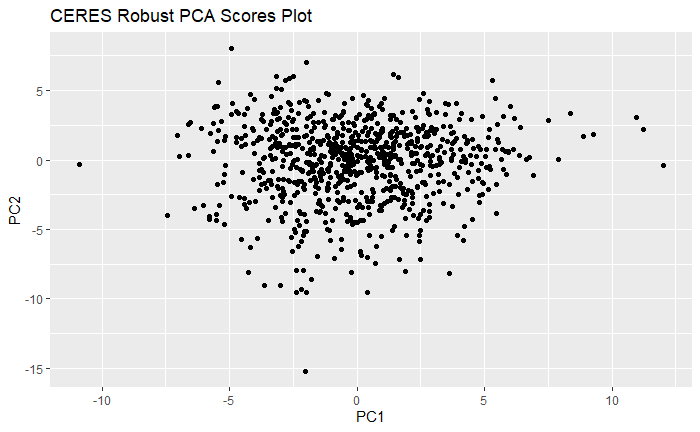

## Visualize cell lines that are omitted from ROBPCA

I am curious about what cell lines are omitted.

```r
outlier_id = data.frame(robpca_ceres@outlier_id)
filtered_cell_lines = merge(meta_data,
                            outlier_id,
                            by.x='DepMap_ID',
                            by.y='robpca_ceres.outlier_id')
```

```r
# Group by
tmp = aggregate(filtered_cell_lines$lineage,
                by=list(filtered_cell_lines$lineage),
                length)
tmp = tmp %>% arrange(x)
tmp$Group.1 = factor(tmp$Group.1,
                     levels=tmp$Group.1[order(tmp$x, decreasing = TRUE)])

# Plot by tissue
ggplot(data=tmp,
       aes(x=Group.1,
           y=x,
           fill=x,
           label=x)) +
  geom_bar(stat='identity',
           position='dodge') +
  coord_flip() +
  labs(y="Number of cell lines removed",
       x="Tissue lineage",
       title="Cell lines removed from robust PCA") +
  guides(fill=guide_legend(title="N cell lines")) +
  geom_text(aes(label=x),
            position=position_dodge(width=0.9),
            hjust=-0.25)
```

[output not shown]

# 4. Compute P-values from CERES Score

We’ll use the ceres data from the Robust PCA analysis.

### Global p-value

Next, we’ll compute the p-values using the data itself. Most of the data lies close to 0 (no activity), while the significant data points lie on the left side of the data distribution. Thus, we’ll compute the left-tailed P-value.

```r
mu = mean(ceres, na.rm=TRUE)
stdev = sd(as.matrix(ceres), na.rm=TRUE)
global_pvals = pnorm(as.numeric(ceres),
                     mean=mu,
                     sd=stdev,
                     lower.tail=TRUE)
pvals = global_pvals
pvals = data.matrix(pvals)
```

Because we are testing several hypotheses, we should control using the FDR.

```r
# Perform FDR Adjustment
adjusted_pval = p.adjust(pvals, method="fdr")
pvals = adjusted_pval
rm(list=c("adjusted_pval", "global_pvals"))
```

## Plot the data distribution

Preprocess data

```r
tmp = data.frame(pvals)
tmp$col = as.factor(tmp$pvals < 0.05)
mlt_ceres = reshape2::melt(ceres)
tmp$ceres = mlt_ceres$value
```

Now let’s plot the data distribution.

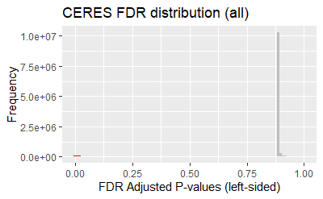

```r
# Plot p-value distribution
ggplot(data.frame(tmp), aes(x=pvals, fill=col)) +
  geom_histogram(bins=100) +
  scale_fill_manual(values = c("TRUE"="red", "FALSE"="gray")) +
  labs(title="CERES FDR distribution (all)",
       x="FDR Adjusted P-values (left-sided)",
       y="Frequency") +
  theme(legend.position="none")
```

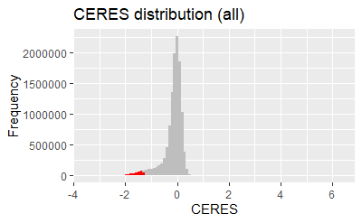

```r
# Plot CERES distribution
ggplot(tmp, aes(x=ceres, fill=col)) +
  geom_histogram(bins=100) +
  scale_fill_manual(values = c("TRUE"="red", "FALSE"="gray")) +
  labs(title="CERES distribution (all)",
       x="CERES",
       y="Frequency") +
  theme(legend.position="none")
```

# 5. Map the CERES scores back to CCLE

The data is currently mapped to a) DepMap identifiers, and b) a hybrid of gene symbols and Entrez IDs.

What we need to do is map it to the following:

- Cancer Cell Line
- Cancer Cell Line Tissue Lineage
- Entrez ID

## Grab CCLE meta data

First, we’ll get relevant meta data

```r
# Linux
#metapath = "~/Data/CRISPR/sample_info.csv"

# Dell
metapath = 'D:/Data/Mappings/CCLE/sample_info.csv'

# Read in meta data
meta_data = read_csv(metapath)
```

[output not shown]

```r
meta_data = meta_data[, c("DepMap_ID",
                        "stripped_cell_line_name",
                        "primary_or_metastasis",
                        "lineage",
                        "lineage_subtype")]
```

## Filter the data to get only NSCLC

Now we need to select specific cell lines that we’re interested in from the NSCLC subtype.

```r
# Lung data needs to be NSCLC and we need to know whether it's from the primary site or if it is metastatic
lung_meta_data = meta_data[meta_data["lineage"]=="lung",]
lung_meta_data = lung_meta_data[lung_meta_data["lineage_subtype"]=="NSCLC",]
lung_meta_data = lung_meta_data[!is.na(lung_meta_data$primary_or_metastasis),]
```

## Separate entrez and gene symbol identifiers

We should clean up the column names for the Project Achilles and store as both symbol and entrez ID separately.

```r
# Save gene symbols
orig_colnames = colnames(data)
all_symbol = as.character(sapply(strsplit(orig_colnames, " "), '[', 1))
#all_symbol = all_symbol[-1]

# Save Entrez ID
all_entrez = as.character(sapply(strsplit(orig_colnames, " "), '[', -1))
all_entrez = str_remove(all_entrez, "[( )]")
all_entrez = str_remove(all_entrez, "[( )]")
all_entrez[1] = all_symbol[1]
```

Combine all the identifiers into a single dataframe.

```r
# All identifiers
all_ids = data.frame(symbol=all_symbol, entrez=all_entrez)
all_ids = all_ids[-1, ]
```

### Map dataset to Entrez IDs

Map everything to Entrez IDs

```r
# Create dataset with gene symbols as ID
data_entrez = ceres
colnames(data_entrez) = all_entrez
```

```
Error in dimnames(x) <- dn :
  length of 'dimnames' [2] not equal to array extent
```

### Map dataset to Gene Symbols

Map everything to Gene Symbols

```r
# Create dataset with gene symbols as ID
data_symbol = data
colnames(data_symbol) = all_symbol

# Create pvalue dataframe
pvals = as.matrix(pvals)
data_dims = dim(ceres)
pvalue_symbol = matrix(pvals,
                   nrow=data_dims[1],
                   ncol=data_dims[2])
pvalue_symbol = data.frame(pvalue_symbol)
colnames(pvalue_symbol) = all_symbol[2:length(pvalue_symbol)]
pvalue_symbol$DepMap_ID = ids
```

## Filter metabolic genes only

Map it back to the human metabolic reconstruction.

```r
recon1_map = "D:/Data/Mappings/Reconstructions/RECON1/RECON1.xlsx"
recon1_genes = readxl::read_excel(recon1_map, sheet="Genes")
recon1_match = merge(all_ids, recon1_genes, by.x="entrez", by.y="Entrez")

data_entrez = data_entrez[, unique(recon1_match$entrez)]
data_entrez$DepMap_ID = ids
```

```
Error: Assigned data `ids` must be compatible with existing data.
x Existing data has 808 rows.
x Assigned data has 655 rows.
i Only vectors of size 1 are recycled.
Run `rlang::last_error()` to see where the error occurred.
```

# 6. Merge metadata to metabolic p-values and CERES scores

Finally, we can the NSCLC data back to RECON1 genes.

```r
# Entrez IDs
merged_lung = merge(lung_meta_data, data_entrez, by='DepMap_ID')
merged_pval = merge(lung_meta_data, pvalue_entrez, by='DepMap_ID')

# Gene Symbols
merged_lung = merge(lung_meta_data, data_symbol, by='DepMap_ID')
merged_pval = merge(lung_meta_data, pvalue_symbol, by='DepMap_ID')
```

## Visualize the NSCLC CRISPR-Cas9 metabolism data mapped to RECON1

Let’s construct the data object used for the visualization.

```r
tmp = merged_pval[, 6:ncol(merged_pval)]
tmp = reshape2::melt(data.frame(tmp))
tmp$col = as.factor(tmp$value < 0.05)
lung_ceres = reshape2::melt(merged_lung[, 6:ncol(merged_lung)])
tmp$ceres = lung_ceres$value
```

Now actually plot the p-values and CERES scores.

```r
# Plot p-value distribution
ggplot(data.frame(tmp), aes(x=value, fill=col)) +
  geom_histogram(bins=100) +
  scale_fill_manual(values = c("TRUE"="red", "FALSE"="gray")) +
  labs(title="CERES NSCLC p-value distribution",
       x="P-values (left-sided)",
       y="Frequency") +
  theme(legend.position="none")

# Plot CERES distribution
ggplot(tmp, aes(x=ceres, fill=col)) +
  geom_histogram(bins=100) +
  scale_fill_manual(values = c("TRUE"="red", "FALSE"="gray")) +
  labs(title="CERES NSCLC distribution",
       x="CERES",
       y="Frequency") +
  theme(legend.position="none")
```

[output not shown]

# 7. Get differentially expressed CERES score by comparing metastatic / primary site using limma-voom

## Data preprocessing

Format the dataset

```r
sample_info = merged_lung[, 1:5]
data = merged_lung[, -c(1:5)]
rownames(data) = sample_info[, 2]
data = t(data)
sample_info = sample_info %>% dplyr::select(2:3)
```

Now we’ll floor positive CERES Scores to 0, and take the absolute value for the CERES Scores

```r
data[data > 0] = 0
data = abs(data)
data[is.na(data)] = 0
```

## Preparing limma-voom data

Now let’s preprocess the data

```r
# Create a DGE List data object
d0 = DGEList(data)
d0 = calcNormFactors(d0)

# Filter out bad data points
cutoff = 1
drop = which(apply(cpm(d0), 1, max) < cutoff)
d = d0[-drop,]
dim(d)
```

```
[1] 1429   74
```

We need to set up the groups we want to compare and the design matrix.

```r
group = as.factor(sample_info$primary_or_metastasis)
design = model.matrix(~0+group)
```

## Run limma-voom

Now let’s run *limma-voom*

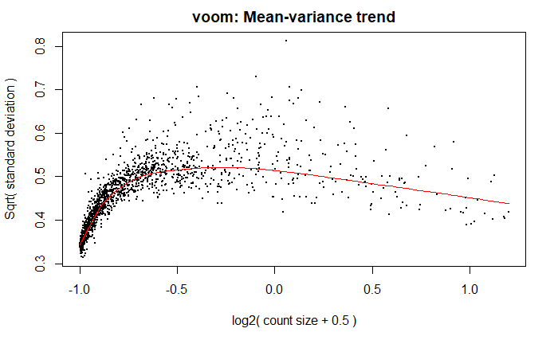

```r
v = voom(d, design, plot=TRUE)
```

```r
fit = lmFit(v, design, method='robust')
result = eBayes(fit, robust=TRUE)
```

```r
top.table = topTable(result)
head(top.table, 20)
```

|  | groupMetastasis | groupPrimary | AveExpr | F | P.Value | adj.P.Val |
| --- | --- | --- | --- | --- | --- | --- |
| 6476 | 10.97819 | 10.91579 | 10.93975 | 401338.5 | 3.176187e-177 | 4.538772e-174 |
| 38 | 10.92515 | 10.86850 | 10.86710 | 383625.3 | 2.381787e-176 | 9.534701e-174 |
| 216 | 10.98820 | 10.91464 | 10.93897 | 382164.4 | 2.823983e-176 | 9.534701e-174 |
| 1607 | 10.92963 | 10.86660 | 10.86974 | 381025.9 | 3.226226e-176 | 9.534701e-174 |
| 144195 | 10.96172 | 10.90735 | 10.92822 | 380740.1 | 3.336144e-176 | 9.534701e-174 |
| 6580 | 10.93963 | 10.86655 | 10.87718 | 377732.7 | 4.752968e-176 | 1.131999e-173 |
| 2982 | 10.95805 | 10.88048 | 10.89649 | 372546.9 | 8.809181e-176 | 1.798331e-173 |
| 6548 | 10.94737 | 10.88319 | 10.88745 | 368197.6 | 1.487883e-175 | 2.657732e-173 |
| 4837 | 10.95337 | 10.88769 | 10.89951 | 365113.6 | 2.165773e-175 | 3.320585e-173 |
| 570 | 10.93579 | 10.87246 | 10.87325 | 363815.3 | 2.539020e-175 | 3.320585e-173 |

```r
write.table(top.table, "clipboard", sep="\t", col.names=TRUE)
```

# 8. Get gene list that are universally lethal across all cell lines

This gene list was determined from Project Score. Specifically, I defined universally lethal genes that are lethal in more than 50% of the cancer cell lines out of > 300.

```r
project_score_file = "D:/Data/CRISPR/Score/41586_2019_1103_MOESM4_ESM/Supplementary Table 3 - Core-Fitness and Context-Specificity Summary_v2.xlsx"
sheet_name = "Filter Genes"

project_score = read_excel(project_score_file, sheet_name)
genes_to_filter = project_score[project_score$`Dependency Score` > 50, ]
```

# 9. Get differentially expressed genes for A549 from CERES score

First, we’ll get the row corresponding to the cancer cell line A549.

```r
a549_ceres = merged_lung[merged_lung$stripped_cell_line_name=="A549",]
a549_ceres[2, ] = merged_pval[merged_pval$stripped_cell_line_name=="A549",]
a549_ceres = a549_ceres[, 6:ncol(a549_ceres)]
a549_ceres = t(a549_ceres)
a549_ceres = data.frame(a549_ceres)
colnames(a549_ceres) = c("CERES", "PValue")
```

Now, let’s grab the metabolic genes that are in RECON1

```r
xname = data.frame(entrez=rownames(a549_ceres))
tmp = merge(xname, recon1_match, by='entrez')
tmp[, 3:4] = NULL
tmp = unique(tmp)
a549_ceres$Symbol = tmp$symbol
```

## Plot Venn Diagram

[figure not shown]

Finally, we’ll grab the genes that have a left-tailed p-value less than 0.05

```r
ubiq_genes = merge(genes_to_filter,
                   sig_a549_ceres,
                   by.x=colnames(genes_to_filter),
                   by.y="row.names")
```

```
Error in merge.data.frame(as.data.frame(x), as.data.frame(y), ...) :
  'by.x' and 'by.y' specify different numbers of columns
```

# 10. Get differentially expressed genes across all NSCLC cell lines

[figure not shown]